# Plotting Magic: Visualizing Weather Data with Matplotlib

Create Eye-Catching Visuals with Python

Author

Michael Borck

[figure not shown]

# Today

- Introduce the importance of data visualisation in Python.
- Learn how to visualise weather data using Matplotlib
- Understand how to create basic plots to represent weather data
- Customise plots to enhance readability and presentation

# Why Visualise Data?

- Simplifies complex data
- Identifies patterns and trends
- Aids in decision-making
- Enhances data storytelling
- Facilitates better communication

# What is Data Visualisation?**

- Visual representation of data
- Uses charts, graphs, and plots
- Helps in understanding data insights

# Popular Libraries in Python**

- **Matplotlib:** Highly customisable, widely used
- **Seaborn:** Built on Matplotlib, easier syntax
- **Plotly:** Interactive visualisations, web-based
- **Bokeh:** Interactive plots, for web apps
- **Altair:** Declarative statistical visualisation

# Workflow

- Find the data you want
- What story do you want to tell
- Pick from the Python Graph Galley
- Get data (upload, wget, etc)
- Implement in notebook (or script)

# Common Visualisation Roles

- Showing change over time
- Showing a part-to-whole composition
- Looking at how data is distributed
- Comparing values between groups
- Observing relationships between variables
- Looking at geographical data

# Python Graph Gallery

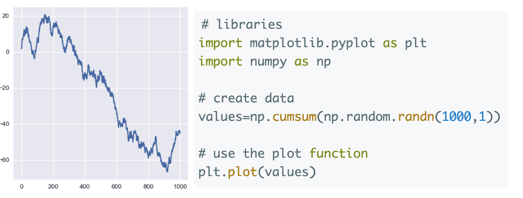

# Dashboard

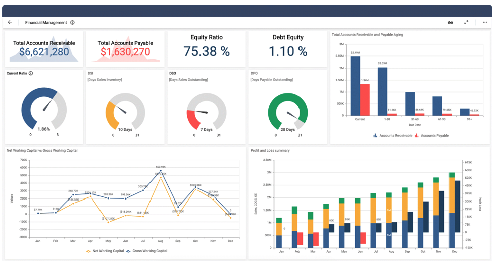

# Introduction to Matplotlib

- Matplotlib is a widely used Python library for creating static, animated, and interactive visualisations
- Import required libraries: `import pandas as pd` and `import matplotlib.pyplot as plt`

# Reading Data

- Read processed weather data from the CSV file created in the previous session

```python
import pandas as pd
df = pd.read_csv('data/processed/processed_weather_data.csv')
```

# Creating Basic Plots

# Line plot for temperature

```python
plt.plot(df['Location'], df['Temperature (C)'], marker='o')
plt.title('Temperature by Location')
plt.xlabel('Location')
plt.ylabel('Temperature (°C)')
plt.xticks(rotation=45)
plt.grid(True)
plt.show()
```

# Bar plot for humidity

```python
plt.bar(df['Location'], df['Humidity (%)'], color='skyblue')
plt.title('Humidity by Location')
plt.xlabel('Location')
plt.ylabel('Humidity (%)')
plt.xticks(rotation=45)
plt.show()
```

# Pie chart for weather description

```python
weather_counts = df['Weather'].value_counts()
plt.pie(weather_counts, labels=weather_counts.index, autopct='%1.1f%%', startangle=140)
plt.title('Weather Description Distribution')
plt.axis('equal')
plt.show()`
```

# Customising Plots

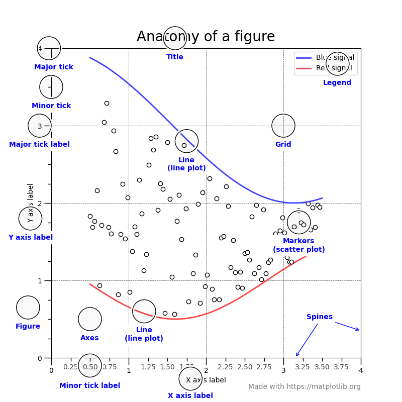

# Adding annotations

```python
plt.annotate(f'Max Temp: {max_temp:.2f}°C', xy=(max_temp_location, max_temp),
                  xytext=(max_temp_location, max_temp+2),
                  arrowprops=dict(facecolor='black', shrink=0.05))
```

# Customising colors and styles

```python
plt.plot(df['Location'], df['Temperature (C)'], marker='o', linestyle='--', color='b')
plt.title('Temperature by Location', fontsize=14, fontweight='bold')
plt.xlabel('Location', fontsize=12)
plt.ylabel('Temperature (°C)', fontsize=12)
plt.xticks(rotation=45)
plt.grid(True, linestyle='--', linewidth=0.5)
plt.show()
```

# Effective Data Visualisation

- Choose the right type of chart
- Maintain clarity and simplicity
- Use colour wisely
- Ensure accuracy and precision
- Tailor visualisations to the audience

# Conclusion

- In this session, we learned how to visualise weather data using Matplotlib
- We created basic plots such as line plots, bar plots, and pie charts, and we customised these plots to improve readability and presentation
- Next session, we will focus on advanced data visualisation techniques using subplots and grids.

# Homework

- Create additional plots to visualise other aspects of the weather data (e.g., wind speed, pressure)
- Experiment with different types of plots and customisations to enhance the visualisations